# Projekt: Wstep do Analizy danych

Arkadiusz Florek

2022-11-11

# Opis projektu

#### Tematyką mojego projektu będzie dyskrimnacja kobiet na przestrzeni lat. Skupie się głownie na :

- Europie
- Krajach bliskiego Wschodu
- Afryce
- Ameryce Północnej(USA,Kanada) - Rozdzielam Ameryke, licząc na jak największy kontrast pomiędzy między obszarami, a moim zdaniem Ameryka Południowa utrudniłaby mi tutaj zadanie.

#### W moim projekcie postaram odpowiedziec się na takie pytania jak :

- Jak na przestrzeni lat zmieniła się dyskryminacja kobiet i czy w aktualnych czasach wciąż pozostaje problemem
- W jakich aspektach naszego życia dyskryminacja jest najbardziej widoczna
- Postaram się pokazać, że siła dyskryminacji zależy także od miejsca zamieszkania
- Jak dużym problemem tak naprawdę jest dyskryminacja

#### Wezmę pod uwagę aspekty życia takie jak : edukacja, polityka, interakcje społeczne, praca. A dokładniej :

- Procent kobiet w parlamencie, mając na uwadze osobiste uwarunkowania bycia wybranym
- Zostanie ofiarą przemocy(ofiary morderstw)
- Stan zdrowia psychicznego
- Możliwość zdobycia wykształcenia podstawowego/średniego(zakładając, że kwestie materialnie i tym podobne są spełnione - założe, że to chodzi tutaj tylko o decyzje rodziców/uwarunkowania społeczne)
- Poziom analfabetyzmu dla ludzi powyżej 15 roku życia

#### Wykorzystam podane zestawy danych:

- Female/ Male population [Liczba osób] - Dla dalszych obliczen
- Female/ Male population ages 0-14 [Liczba osób] - Posluzy do obliczen zwiazanych z edukacja
- Female / Male suicide / 100 k [Liczba osób] - Pomoze w jakims stopniu pokazac poziom zadowolenia z zycia
- Female / Male murdered / 100 k [Liczba osób] - Pokaze jak czesto ofiara przemocy ulegaja kobiet a jak mezczyzni
- Percentage of woman in national parliments [%] - Sprawdzi, czy istnieje dyskrimancja w polityce
- Female / Male adult literacy rate [wskaznik, %] - Poziom analfabetyzmu
- Female/Male out of school[Liczba osób] - Pokaze dostepnosc podstawowej edukacji
- Woman who believe a husband is justfied in beating his wife(z powodow które opisze poniżej) [%] - Posłuży do pokazania sposobu myślenia kobiet na temat własnej pozycji w spoleczenstwie

Powody do bicia żony: gdy wyjdzie(gdziekolwiek) bez pytania, gdzy sie kluci, gdy przypali jedzenie, gdy zaniedba dzieci, gdy odmówi seksu.

#### Wykorzystam podane pakiety :

- tidyr
- dplyr
- stringr
- ggplot2

#### Postawione hipotezy badawcze :

- Głowna hipoteza badawacza, która postaram się udowodnic to, ze dyskrimnacja kobiet zalezy(i to mocno) od miejsca.
- Poboczna hipoteza, bedzie, iz sytuacja kobiet nie ulega znaczacej zmianie

#### Postaram sie to udowodnic badajac po drodze nastepujace hipotezy:

- % kobiet w parlamencie(czyli pozycje tak zwanej wladzy) jest dosc niski i nie wykazuje trendu wzrostowego(co wskazywaloby na poprawe sytuacji)
- Kobiety padaja czesciej przemocy fizycznej i nie ulega to zmianie
- Wskaznnik analfabetyzmu pozostaje wysoki od lat w przypadku kobiet z krajow bliskiego wschodu oraz afryki
- Kobiety duzo czesciej nie zostaja przyjmowane do szkol ze wzgledu na plec
- Jak kobiety odbierają swoje miejsce w społeczeństwie(co jest im wpajane)

# Wczytanie oraz porządkowanie zestawów danych

### Wczytywanie pakietow

```r
library(tidyr)
library(dplyr)
library(stringr)
library(ggplot2)
```

### Grupowanie krajów według wcześniejszych ustaleń

```r
kraje_bliskiego_wschodu = c("Cyprus","Syria","Iraq","Iran","Isreal","Jordan","Saudi Arabia","Qatar","United Arab Emirates","Yemen","Oman","Kuwait")

kraje_amerki_polnocej = c("USA","Canada")

kraje_europy = c("Albania","Austria","Belgium","Bosnia and Herzegovina","Bulgaria"  ,"Croatia","Czech Republic","Denmark","Finland","France","Germany","Greece","Hungary","Iceland","Ireland","Italy","Montenegro","Netherlands","Norway","Poland","Portugal","Romania","Serbia","Slovak Republic","Slovenia","Spain","Sweden","Switzerland","Turkey","United Kingdom")

kraje_afryki = c("Algeria","Angola","Benin","Botswana","Burkina Faso","Burundi","Cameroon","Central African Republic","Chad","Comoros","Djibouti","Egypt","Equatorial Guinea","Eritrea","Ethiopia","Gabon","Gambia","Ghana","Guinea","Guinea-Bissau","Kenya","Lesotho","Liberia","Libya","Madagascar","Malawi","Mali","Mauritania","Mauritius","Morocco","Mozambique","Namibia","Niger","Nigeria","Reunion","Rwanda","Senegal","Sierra Leone","Somalia","South Africa","Sudan","Swaziland","Tanzania","Togo","Tunisia","Uganda","Zambia","Zimbabwe")
```

## Wczytywanie danych

```r
# Wczytanie nazw plikow dla ulatwienia
nazwy_plikow = read.csv(file="C:/Users/arekf/Desktop/studia 3 sesmtr/Wstęp do analizy danych/zestawydanych_doprojektu/nazwy.txt",sep = "\n")


beating_wife = read.csv(file = "C:/Users/arekf/Desktop/studia 3 sesmtr/Wstęp do analizy danych/zestawydanych_doprojektu/Beating_wife.csv",sep=",",header = TRUE )

human_index_m = read.csv(file = "C:/Users/arekf/Desktop/studia 3 sesmtr/Wstęp do analizy danych/zestawydanych_doprojektu/Human_capital_index_m.csv",sep=",",header = TRUE )

human_index_f = read.csv(file = "C:/Users/arekf/Desktop/studia 3 sesmtr/Wstęp do analizy danych/zestawydanych_doprojektu/Human_capital_index_m.csv",sep=",",header = TRUE )

literacy_rate_m = read.csv(file = "C:/Users/arekf/Desktop/studia 3 sesmtr/Wstęp do analizy danych/zestawydanych_doprojektu/Literacy_rate_age15_m.csv",sep=",",header = TRUE )

literacy_rate_f = read.csv(file = "C:/Users/arekf/Desktop/studia 3 sesmtr/Wstęp do analizy danych/zestawydanych_doprojektu/Literacy_rate_age15_f.csv",sep=",",header = TRUE )

murdered_f = read.csv(file = "C:/Users/arekf/Desktop/studia 3 sesmtr/Wstęp do analizy danych/zestawydanych_doprojektu/murdered_100k_f.csv",sep=",",header = TRUE )

murdered_m = read.csv(file = "C:/Users/arekf/Desktop/studia 3 sesmtr/Wstęp do analizy danych/zestawydanych_doprojektu/murdered_100k_m.csv",sep=",",header = TRUE )

out_of_school_m = read.csv(file = "C:/Users/arekf/Desktop/studia 3 sesmtr/Wstęp do analizy danych/zestawydanych_doprojektu/Out_of_school_m.csv",sep=",",header = TRUE )

out_of_school_f = read.csv(file = "C:/Users/arekf/Desktop/studia 3 sesmtr/Wstęp do analizy danych/zestawydanych_doprojektu/Out_of_school_f.csv",sep=",",header = TRUE )

parlament = read.csv(file = "C:/Users/arekf/Desktop/studia 3 sesmtr/Wstęp do analizy danych/zestawydanych_doprojektu/parlament_%_f.csv",sep=",",header = TRUE )

populacja_m = read.csv(file = "C:/Users/arekf/Desktop/studia 3 sesmtr/Wstęp do analizy danych/zestawydanych_doprojektu/Populacja_m.csv",sep=",",header = TRUE )

populacja_f = read.csv(file = "C:/Users/arekf/Desktop/studia 3 sesmtr/Wstęp do analizy danych/zestawydanych_doprojektu/Populacja_f.csv",sep=",",header = TRUE )

populacja_014_f = read.csv(file = "C:/Users/arekf/Desktop/studia 3 sesmtr/Wstęp do analizy danych/zestawydanych_doprojektu/populacja_014_f.csv",sep=",",header = TRUE )

populacja_014_m = read.csv(file = "C:/Users/arekf/Desktop/studia 3 sesmtr/Wstęp do analizy danych/zestawydanych_doprojektu/populacja_014_f.csv",sep=",",header = TRUE )

suicide_f = read.csv(file = "C:/Users/arekf/Desktop/studia 3 sesmtr/Wstęp do analizy danych/zestawydanych_doprojektu/suicide_100k_f.csv",sep=",",header = TRUE )

suicide_m = read.csv(file = "C:/Users/arekf/Desktop/studia 3 sesmtr/Wstęp do analizy danych/zestawydanych_doprojektu/suicide_100k_m.csv",sep=",",header = TRUE )
```

### Czyszczenie i grupowanie danych

#### Uzyję mediany do uśrednienia wartości dla danego regionu, ze wględu na dużo przypadków odstających

```r
grupowanie_danych_bez_ameryki= function(x)
{
  glowna = x %>%
    filter(country %in% kraje_bliskiego_wschodu)  %>%
    group_by(year) %>%
    summarise(bliski_wschod = median(wartosc,na.rm=TRUE))

  temp1 = x %>%
    filter(country %in% kraje_europy)  %>%
    group_by(year) %>%
    summarise(europa = median(wartosc,na.rm=TRUE))


  temp2 = x %>%
    filter(country %in% kraje_afryki)  %>%
    group_by(year) %>%
    summarise(afryka = median(wartosc,na.rm=TRUE))


  glowna = glowna %>%
    mutate(europa=temp1$europa,afryka = temp2$afryka)

  return (glowna)
}





grupowanie_danych = function(x)
{
  glowna = x %>%
    filter(country %in% kraje_bliskiego_wschodu)  %>%
    group_by(year) %>%
    summarise(bliski_wschod = median(wartosc,na.rm=TRUE))

  temp = x %>%
    filter(country %in% kraje_amerki_polnocej)  %>%
    group_by(year) %>%
    summarise(ameryka = median(wartosc,na.rm=TRUE))


  temp1 = x %>%
    filter(country %in% kraje_europy)  %>%
    group_by(year) %>%
    summarise(europa = median(wartosc,na.rm=TRUE))


  temp2 = x %>%
    filter(country %in% kraje_afryki)  %>%
    group_by(year) %>%
    summarise(afryka = median(wartosc,na.rm=TRUE))


  glowna = glowna %>%
    mutate(ameryka = temp$ameryka,europa=temp1$europa,afryka = temp2$afryka)

  return (glowna)
}



czyszczenie_danych_indeksowych = function(zestaw,am)
{
  zestaw = zestaw%>%
    gather(year,wartosc,-country,)%>%  # Przeksztalcam dane, laczac je w 3 kolumny
    arrange(country)%>%
    mutate(year = gsub("X","",year))%>%  # Usuwam X z roku
    mutate(wartosc = as.numeric(wartosc))

  if(am == 1)
  {
    zestaw = grupowanie_danych(zestaw)
  }
  else
  {
    zestaw = grupowanie_danych_bez_ameryki(zestaw)
  }
  return(zestaw)
}


czyszczenie_danych_100k = function(zestaw)
{
  zestaw = zestaw%>%
    gather(year,wartosc,-country,)%>%  # Przeksztalcam dane, laczac je w 3 kolumny
    arrange(country)%>%
    mutate(year = gsub("X","",year))%>%  # Usuwam X z roku
    mutate(wartosc = as.numeric(wartosc))%>%
    mutate(wartosc = wartosc * 100000)

  zestaw = grupowanie_danych(zestaw)

  return(zestaw)
}

czyszczenie_danych = function(zestaw)
{
  zestaw = zestaw%>%
    gather(year,wartosc,-country,)%>%  # Przeksztalcam dane, laczac je w 3 kolumny
    arrange(country)%>%
    mutate(year = gsub("X","",year))%>%  # Usuwam X z roku
    mutate(koncowka = str_sub(wartosc,-1))%>% # Pobieram ostatnia literke w wartosc("M" lub "k")
    mutate(wartosc = gsub("M","",wartosc),wartosc = gsub( "k","",wartosc))%>% # Usuwam koncowki z wartosci
    mutate(wartosc = as.numeric(wartosc))%>% # Przeksztalcam wartosc na dane liczbowe
    mutate(wartosc = case_when(koncowka == "M" ~ wartosc*1000000, # Zmieniam dane na podstawie koncowki
                             koncowka == "k" ~ wartosc*1000,
                             TRUE ~ wartosc))%>%
    select(country,year,wartosc) # Usuwam kolumne koncowki

  zestaw = grupowanie_danych(zestaw)

  return(zestaw)
}

# Zestawy danych z wartoscia do naprawy : 6 zestawow

out_of_school_f = czyszczenie_danych(out_of_school_f)
tail(out_of_school_f,3)
```

```
## # A tibble: 3 × 5
##   year  bliski_wschod ameryka europa afryka
##   <chr>         <dbl>   <dbl>  <dbl>  <dbl>
## 1 2019          67129      NA   7445 111000
## 2 2020         112800      NA   2610 205000
## 3 2021             NA      NA     NA  50350
```

```r
out_of_school_m= czyszczenie_danych(out_of_school_m)
tail(out_of_school_m,3)
```

```
## # A tibble: 3 × 5
##   year  bliski_wschod ameryka europa afryka
##   <chr>         <dbl>   <dbl>  <dbl>  <dbl>
## 1 2019          65345      NA  13250  85500
## 2 2020         116300      NA   4340 185000
## 3 2021             NA      NA     NA  66650
```

```r
populacja_014_f = czyszczenie_danych(populacja_014_f)
tail(populacja_014_f,3)
```

```
## # A tibble: 3 × 5
##   year  bliski_wschod ameryka europa  afryka
##   <chr>         <dbl>   <dbl>  <dbl>   <dbl>
## 1 2018        1680000 2870000 646000 3370000
## 2 2019        1670000 2910000 644000 3440000
## 3 2020        1640000 2930000 642000 3520000
```

```r
populacja_014_m = czyszczenie_danych(populacja_014_m)
tail(populacja_014_m,3)
```

```
## # A tibble: 3 × 5
##   year  bliski_wschod ameryka europa  afryka
##   <chr>         <dbl>   <dbl>  <dbl>   <dbl>
## 1 2018        1680000 2870000 646000 3370000
## 2 2019        1670000 2910000 644000 3440000
## 3 2020        1640000 2930000 642000 3520000
```

```r
populacja_f = czyszczenie_danych(populacja_f)
tail(populacja_f,3)
```

```
## # A tibble: 3 × 5
##   year  bliski_wschod  ameryka  europa  afryka
##   <chr>         <dbl>    <dbl>   <dbl>   <dbl>
## 1 2018        4920000 18700000 4785000 7560000
## 2 2019        4990000 18900000 4815000 7740000
## 3 2020        5040000 19200000 4815000 7970000
```

```r
populacja_m = czyszczenie_danych(populacja_m)
tail(populacja_m,3)
```

```
## # A tibble: 3 × 5
##   year  bliski_wschod  ameryka  europa  afryka
##   <chr>         <dbl>    <dbl>   <dbl>   <dbl>
## 1 2018        6680000 18400000 4500000 7480000
## 2 2019        6770000 18700000 4510000 7700000
## 3 2020        6840000 18900000 4520000 7920000
```

```r
# Zestawy danych z indeksami/% : 6

# Drugi argument jest informacja czy grupujemy dane dla ameryki, poneiwaz niektore zestawy nie posiadaja tego regionu
human_index_f = czyszczenie_danych_indeksowych(human_index_f,1)
tail(human_index_f,3)
```

```
## # A tibble: 3 × 5
##   year  bliski_wschod ameryka europa afryka
##   <chr>         <dbl>   <dbl>  <dbl>  <dbl>
## 1 2018          0.611    0.81  0.772  0.397
## 2 2019         NA       NA    NA     NA
## 3 2020          0.604    0.81  0.766  0.401
```

```r
human_index_m = czyszczenie_danych_indeksowych(human_index_m,1)
tail(human_index_m,3)
```

```
## # A tibble: 3 × 5
##   year  bliski_wschod ameryka europa afryka
##   <chr>         <dbl>   <dbl>  <dbl>  <dbl>
## 1 2018          0.611    0.81  0.772  0.397
## 2 2019         NA       NA    NA     NA
## 3 2020          0.604    0.81  0.766  0.401
```

```r
literacy_rate_f = czyszczenie_danych_indeksowych(literacy_rate_f,0)
tail(literacy_rate_f,3)
```

```
## # A tibble: 3 × 4
##   year  bliski_wschod europa afryka
##   <chr>         <dbl>  <dbl>  <dbl>
## 1 2009           92.9   91.1   43.8
## 2 2010           89.2   92.6   62.5
## 3 2011           80     97.4   59
```

```r
literacy_rate_m = czyszczenie_danych_indeksowych(literacy_rate_m,0)
tail(literacy_rate_m,3)
```

```
## # A tibble: 3 × 4
##   year  bliski_wschod europa afryka
##   <chr>         <dbl>  <dbl>  <dbl>
## 1 2009           95.1   97.4   67.4
## 2 2010           95.8   97.9   76.9
## 3 2011           90.6   99.2   80.5
```

```r
parlament = czyszczenie_danych_indeksowych(parlament,1)
tail(parlament,3)
```

```
## # A tibble: 3 × 5
##   year  bliski_wschod ameryka europa afryka
##   <chr>         <dbl>   <dbl>  <dbl>  <dbl>
## 1 2019           14.3    33.2   30.6   20
## 2 2020           11.5    33.9   31.5   20.8
## 3 2021           11.5    34.4   35.2   20.8
```

```r
beating_wife = czyszczenie_danych_indeksowych(beating_wife,0)

# Zestawy danych podzielone /100k : 4
suicide_f = czyszczenie_danych_100k(suicide_f)
tail(suicide_f,3)
```

```
## # A tibble: 3 × 5
##   year  bliski_wschod ameryka europa afryka
##   <chr>         <dbl>   <dbl>  <dbl>  <dbl>
## 1 2014         184000      NA 403000 193470
## 2 2015         176000      NA 452500 216055
## 3 2016         101000      NA 483000 231000
```

```r
suicide_m = czyszczenie_danych_100k(suicide_m)
tail(suicide_m,3)
```

```
## # A tibble: 3 × 5
##   year  bliski_wschod ameryka  europa  afryka
##   <chr>         <dbl>   <dbl>   <dbl>   <dbl>
## 1 2014         168000      NA 1405000  758150
## 2 2015         678000      NA 1500000  604210
## 3 2016         671000      NA 1640000 1290000
```

```r
murdered_f = czyszczenie_danych_100k(murdered_f)
tail(murdered_f,3)
```

```
## # A tibble: 3 × 5
##   year  bliski_wschod ameryka europa afryka
##   <chr>         <dbl>   <dbl>  <dbl>  <dbl>
## 1 2014          84850      NA  52400  84665
## 2 2015          54300      NA  53100  59015
## 3 2016          80500      NA  48700 133000
```

```r
murdered_m = czyszczenie_danych_100k(murdered_m)
tail(murdered_m,3)
```

```
## # A tibble: 3 × 5
##   year  bliski_wschod ameryka europa afryka
##   <chr>         <dbl>   <dbl>  <dbl>  <dbl>
## 1 2014          97500      NA  85500 126400
## 2 2015         231000      NA  81900 185950
## 3 2016         171000      NA  85700 158000
```

# Merytoryczna część projektu

## Kobiety w parlamencie, to znaczy na stanowiskach “władzy”

#### W tym rozdziale postaram się pokazać nierówność jaka występuje na jednych z najważniejszych stanowisk jakie występują w naszym społeczeństwie, czyli w parlamencie. Zacznę od porównania danych w każdym z regionów. Przedstawię % kobiet w parlamencie oraz populację kobiet i mężczyzn w danym regionie. Nastpęnie porównam regiony.

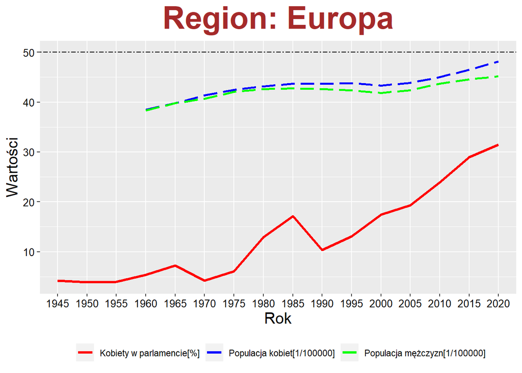

```r
kraje = c("bliski_wschod","europa","ameryka","afryka")
kon = c("5","0")

# Zamiana,aby dane byly pokazywane co 5 lat
parli = parlament
parli = subset(parli,str_ends(year,"0") | str_ends(year,"5"))


pop_f = populacja_f
pop_f = subset(pop_f,str_ends(year,"0") | str_ends(year,"5"))
pop_f = pop_f %>%
  mutate(across(kraje,function(x) x/100000))


pop_m = populacja_m
pop_m = subset(pop_m,str_ends(year,"0") | str_ends(year,"5"))
pop_m = pop_m %>%
  mutate(across(kraje,function(x) x/100000))


legend = c("parl"="red","popf"="blue","popm"="green")
# Wykres dla Europy

ggplot(NULL,aes(year,europa,group=1)) +
  geom_line(data=parli,size=1.06,aes(color="parl")) +
  geom_line(data=pop_f,size = 0.9,linetype="longdash",aes(color="popf")) +
  geom_line(data = pop_m,size = 0.9,linetype="longdash",aes(color="popm")) +
  geom_hline(yintercept = 50,col="black",linetype="twodash")+
  xlab("Rok")+
  ylab("Wartości")+
  scale_color_manual(name="",values = legend,labels = c("Kobiety w parlamencie[%]","Populacja kobiet[1/100000]","Populacja mężczyzn[1/100000]"))+
  ggtitle("Region: Europa") +
  theme(
    plot.title = element_text(hjust = 0.5,vjust = 1,face='bold',size=30,colour =           "brown"),
    axis.text = element_text(size=(10),colour = "black"),
    axis.title = element_text(size = (15)),
    legend.position = "bottom")
```

#### Z wykresu możemy zauważyć, iż stosunek kobiet do mężczyzn znacząco się nie zmienił.mimo tego widzimy bardzo dużą dysproporcje(poniżej 15% kobiet w parlamencie) występującą aż do 1985 roku. Następnie wystąpił spadek w 1990 roku i od następnych lat możemy zauważyc wzrostowy trend liniowy dązący do pożądanej wartości[50 %]. Biorąc pod uwagę personalne predyspozycje na dane stanowisko, można stwierdzić, że Europa idzie w dobrym kierunku, lecz potrzebuje jeszcze czasu na polepszenie sytaucji.

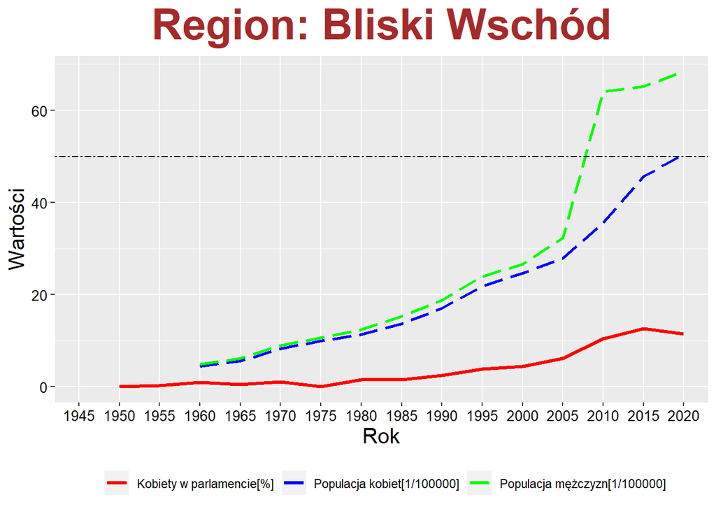

```r
# Wykres dla Bliskiego Wschodu

ggplot(NULL,aes(year,bliski_wschod,group=1)) +
  geom_line(data=parli,size=1.06,aes(color="parl")) +
  geom_line(data=pop_f,size = 0.9,linetype="longdash",aes(color="popf")) +
  geom_line(data = pop_m,size = 0.9,linetype="longdash",aes(color="popm")) +
  geom_hline(yintercept = 50,col="black",linetype="twodash")+
  xlab("Rok")+
  ylab("Wartości")+
  scale_color_manual(name="",values = legend,labels = c("Kobiety w parlamencie[%]","Populacja kobiet[1/100000]","Populacja mężczyzn[1/100000]"))+
  ggtitle("Region: Bliski Wschód") +
  theme(
    plot.title = element_text(hjust = 0.5,vjust = 1,face='bold',size=30,colour =           "brown"),
    axis.text = element_text(size=(10),colour = "black"),
    axis.title = element_text(size = (15)),
    legend.position = "bottom")
```

#### Z wykresu można od razu stwierdzić, że sytaucja nie prezentuje się najlepiej(największa wartość to mniej niż 15%). Widać znaczący wzrost populacji mężczyzn w latach 2005-2010, co mogło przełożyć się na pózniejsze wyniki, jednakże sytuacja nie jest najlepsza i nic nie wskazuje na jej poprawe w najbliższej przyszłości.

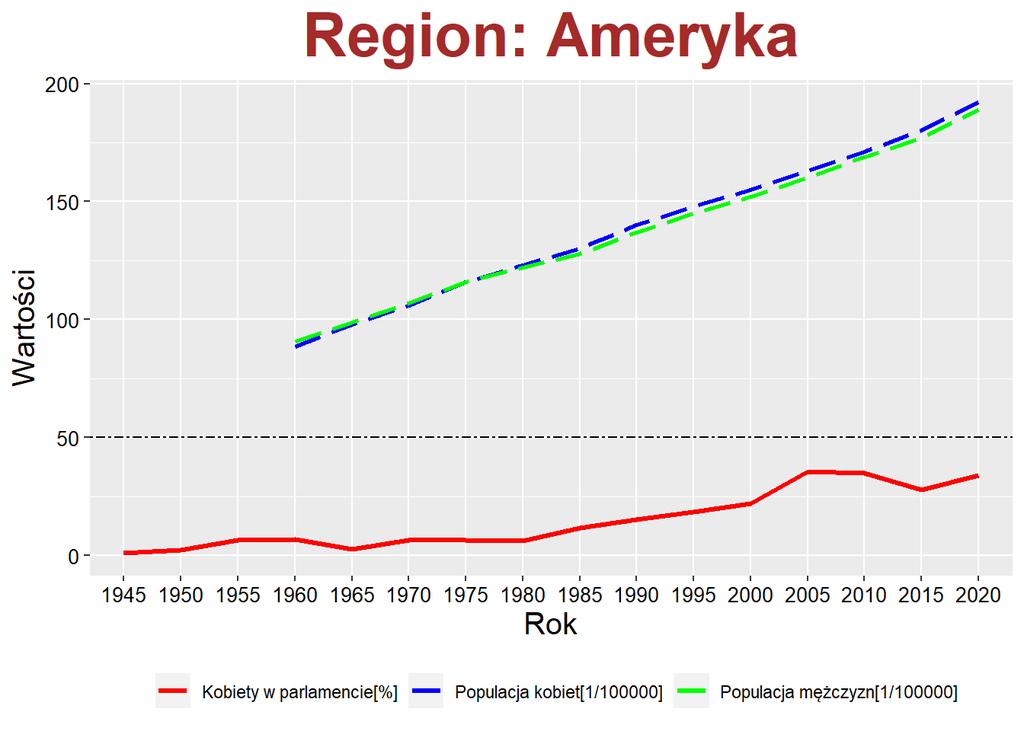

```r
# Wykres dla Ameryki

ggplot(NULL,aes(year,ameryka,group=1)) +
  geom_line(data=parli,size=1.06,aes(color="parl")) +
  geom_line(data=pop_f,size = 0.9,linetype="longdash",aes(color="popf")) +
  geom_line(data = pop_m,size = 0.9,linetype="longdash",aes(color="popm")) +
  geom_hline(yintercept = 50,col="black",linetype="twodash")+
  xlab("Rok")+
  ylab("Wartości")+
  scale_color_manual(name="",values = legend,labels = c("Kobiety w parlamencie[%]","Populacja kobiet[1/100000]","Populacja mężczyzn[1/100000]"))+
  ggtitle("Region: Ameryka") +
  theme(
    plot.title = element_text(hjust = 0.5,vjust = 1,face='bold',size=30,colour =           "brown"),
    axis.text = element_text(size=(10),colour = "black"),
    axis.title = element_text(size = (15)),
    legend.position = "bottom")
```

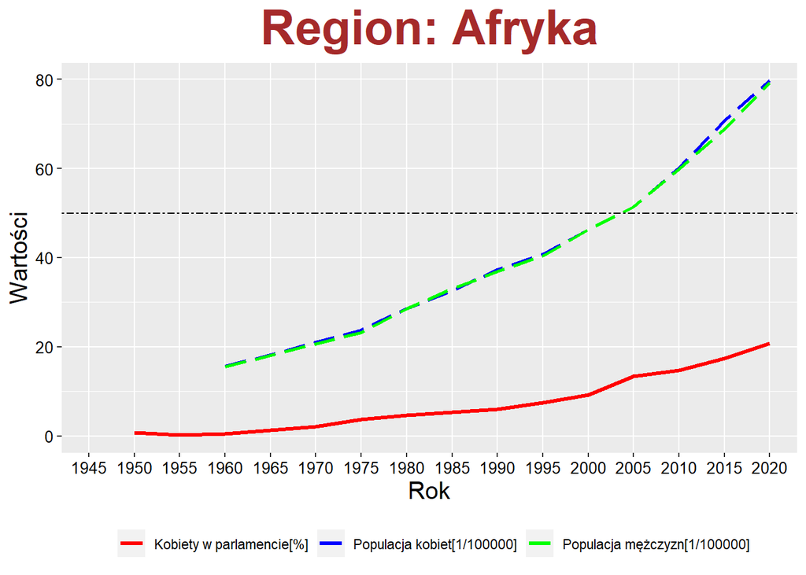

```r
# Wykres dla Afrryki

ggplot(NULL,aes(year,afryka,group=1)) +
  geom_line(data=parli,size=1.06,aes(color="parl")) +
  geom_line(data=pop_f,size = 0.9,linetype="longdash",aes(color="popf")) +
  geom_line(data = pop_m,size = 0.9,linetype="longdash",aes(color="popm")) +
  geom_hline(yintercept = 50,col="black",linetype="twodash")+
  xlab("Rok")+
  ylab("Wartości")+
  scale_color_manual(name="",values = legend,labels = c("Kobiety w parlamencie[%]","Populacja kobiet[1/100000]","Populacja mężczyzn[1/100000]"))+
  ggtitle("Region: Afryka") +
  theme(
    plot.title = element_text(hjust = 0.5,vjust = 1,face='bold',size=30,colour =           "brown"),
    axis.text = element_text(size=(10),colour = "black"),
    axis.title = element_text(size = (15)),
    legend.position = "bottom")
```

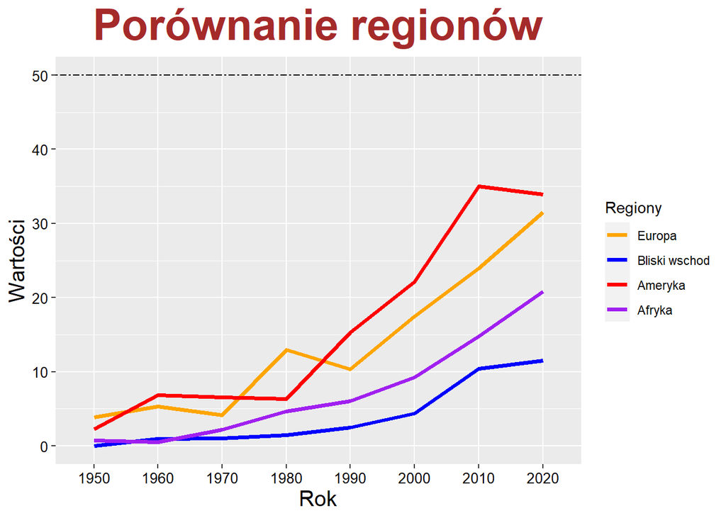

```r
# Zamiana,aby dane byly pokazywane co 10 lat
parl = parlament
parl = subset(parli,str_ends(year,"0"))

# Wykres dla porównania regionów

legend2 = c("er"="orange","bw"="blue","am"="red","af"="purple")
ggplot(parl,aes(x=year)) +
  geom_line(aes(color="er",y=europa,group=1),size=1.25) +
  geom_line(aes(color="bw",y=bliski_wschod,group=1),size=1.25) +
  geom_line(aes(color="am",y=ameryka,group=1),size=1.25) +
  geom_line(aes(color="af",y=afryka,group=1),size=1.25) +
  geom_hline(yintercept = 50,col="black",linetype="twodash")+
  xlab("Rok")+
  ylab("Wartości")+
  scale_color_manual(name="Regiony",values = legend2,labels = c("Europa","Bliski wschod","Ameryka","Afryka"))+
  ggtitle("Porównanie regionów") +
  theme(
    plot.title = element_text(hjust = 0.5,vjust = 1,face='bold',size=30,colour =           "brown"),
    axis.text = element_text(size=(10),colour = "black"),
    axis.title = element_text(size = (15)),
    legend.position = "right")
```

#### Jak widać na wykresie najlepiej radzącymi sobie regionami są: Europa i Ameryka, natomiast Afryka i Bliski Wschód są dośc daleko w tyle, co potwierdza jak narazie moją główną hipotezę badawczą. Warto wspomnieć, że Afryka jest na dobrej drodze, jendak rozwija się powolniej od Europy i Ameryki.

## Poziom “niezadowolenia” z życia

#### W tym rozdziale przedstawię stosunek liczby samobójstw danej płci do ich populacji w danym regionie w celu sformułowania odpowiednich wniosków. Użyję wzoru:

$$Wskaznik =
\frac{LiczbaSamobójstw}{Populacja} * 100$$

#### Potraktuje liczbę samobójstw jako wskaznik ogólnego “niezadowolenia” z życia i tak też będę interpretował otrzymane wyniki. Następnie porównam różnice wskaznikow i przedstawię je na wykresie:

$$Różnica = WskaznikMęczyzn -
WskaznikKobiet$$

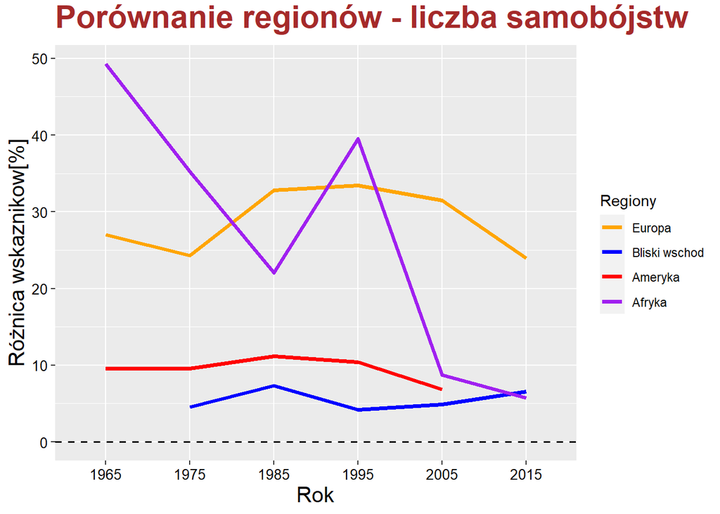

```r
# Tworzenie wskaznika dla kobiet

samobojstwa_f = suicide_f %>%
  filter(as.numeric(year)>=1960)


wskaznik_sam_f = merge(samobojstwa_f,populacja_f,by="year")


wskaznik_sam_f = wskaznik_sam_f %>%
  mutate(bliski_wschod = bliski_wschod.x/bliski_wschod.y*100)%>%
  mutate(europa = europa.x/europa.y*100)%>%
  mutate(ameryka = ameryka.x/ameryka.y*100)%>%
  mutate(afryka = afryka.x/afryka.y*100)%>%
  select(year,bliski_wschod,europa,afryka,ameryka)

wskaznik_sam_f = wskaznik_sam_f %>%
  filter(str_ends(year,"5"))



# Tworzenie wskaznika dla Mezczyzn

samobojstwa_m = suicide_m %>%
  filter(as.numeric(year)>=1960)


wskaznik_sam_m = merge(samobojstwa_m,populacja_m,by="year")


wskaznik_sam_m = wskaznik_sam_m %>%
  mutate(bliski_wschod = bliski_wschod.x/bliski_wschod.y*100)%>%
  mutate(europa = europa.x/europa.y*100)%>%
  mutate(ameryka = ameryka.x/ameryka.y*100)%>%
  mutate(afryka = afryka.x/afryka.y*100)%>%
  select(year,bliski_wschod,europa,afryka,ameryka)

wskaznik_sam_m = wskaznik_sam_m %>%
  filter(str_ends(year,"5"))


# Robie roznice wskaznikow : Wskaznik mezczyzn - kobiet

roznica_sam = merge(wskaznik_sam_m,wskaznik_sam_f,by="year")


roznica_sam = roznica_sam %>%
  mutate(bliski_wschod = bliski_wschod.x-bliski_wschod.y)%>%
  mutate(europa = europa.x-europa.y)%>%
  mutate(ameryka = ameryka.x-ameryka.y)%>%
  mutate(afryka = afryka.x-afryka.y)%>%
  select(year,bliski_wschod,europa,afryka,ameryka)



legend2 = c("er"="orange","bw"="blue","am"="red","af"="purple")
ggplot(roznica_sam,aes(x=year)) +
  geom_line(aes(color="er",y=europa,group=1),size=1.25) +
  geom_line(aes(color="bw",y=bliski_wschod,group=1),size=1.25) +
  geom_line(aes(color="am",y=ameryka,group=1),size=1.25) +
  geom_line(aes(color="af",y=afryka,group=1),size=1.25) +
  geom_hline(yintercept = 0,size=0.7,linetype="dashed") +
  xlab("Rok")+
  ylab("Różnica wskaznikow[%]")+
  scale_color_manual(name="Regiony",values = legend2,labels = c("Europa","Bliski wschod","Ameryka","Afryka"))+
  ggtitle("Porównanie regionów - liczba samobójstw") +
  theme(
    plot.title = element_text(hjust = 0,vjust = 1.5,face='bold',size=22,colour =           "brown"),
    axis.text = element_text(size=(10),colour = "black"),
    axis.title = element_text(size = (15)),
    legend.position = "right")
```

## Przemoc fizyczna

#### W tym rozdziale zajmę się przemocą fizyczną, bazując na liczbie morderstw. Po raz kolejny użyję wzoru jaka część populacji danego regionu pada ofiarą przemocy:

$$Wskaznik =
\frac{LiczbaMorderstw}{Populacja} * 100$$

#### Następnie policzę różnicę wskaznikow i przedstawię je na wykresie porównując regiony.

$$Różnica = WskaznikMęczyzn -
WskaznikKobiet$$

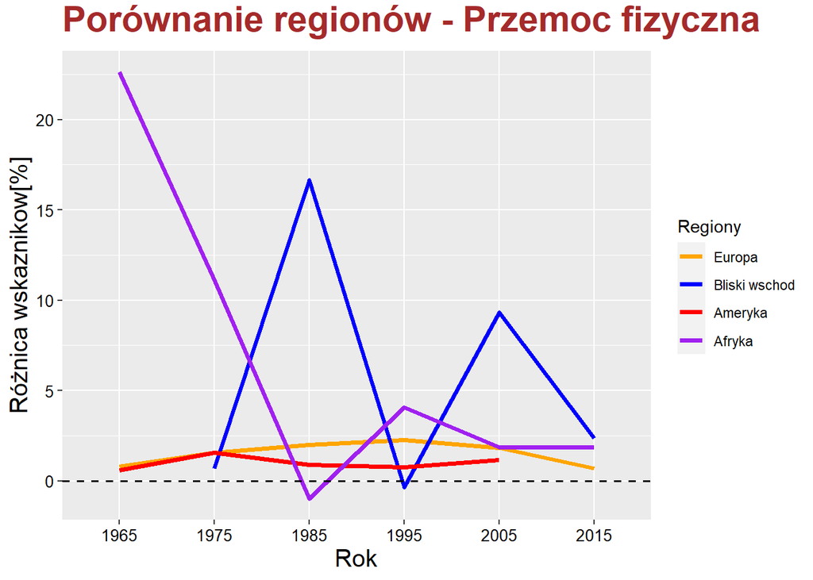

```r
# Tworzenie wskaznika dla kobiet

morder_f = murdered_f %>%
  filter(as.numeric(year)>=1960)


wskaznik_mur_f = merge(morder_f,populacja_f,by="year")


wskaznik_mur_f = wskaznik_mur_f %>%
  mutate(bliski_wschod = bliski_wschod.x/bliski_wschod.y*100)%>%
  mutate(europa = europa.x/europa.y*100)%>%
  mutate(ameryka = ameryka.x/ameryka.y*100)%>%
  mutate(afryka = afryka.x/afryka.y*100)%>%
  select(year,bliski_wschod,europa,afryka,ameryka)

wskaznik_mur_f = wskaznik_mur_f %>%
  filter(str_ends(year,"5"))



# Tworzenie wskaznika dla Mezczyzn

morder_m = murdered_m %>%
  filter(as.numeric(year)>=1960)


wskaznik_mur_m = merge(morder_m,populacja_m,by="year")


wskaznik_mur_m = wskaznik_mur_m %>%
  mutate(bliski_wschod = bliski_wschod.x/bliski_wschod.y*100)%>%
  mutate(europa = europa.x/europa.y*100)%>%
  mutate(ameryka = ameryka.x/ameryka.y*100)%>%
  mutate(afryka = afryka.x/afryka.y*100)%>%
  select(year,bliski_wschod,europa,afryka,ameryka)

wskaznik_sam_m = wskaznik_sam_m %>%
  filter(str_ends(year,"5"))


# Robie roznice wskaznikow : Wskaznik mezczyzn - kobiet

roznica_mur = merge(wskaznik_mur_m,wskaznik_mur_f,by="year")


roznica_mur = roznica_mur %>%
  mutate(bliski_wschod = bliski_wschod.x-bliski_wschod.y)%>%
  mutate(europa = europa.x-europa.y)%>%
  mutate(ameryka = ameryka.x-ameryka.y)%>%
  mutate(afryka = afryka.x-afryka.y)%>%
  select(year,bliski_wschod,europa,afryka,ameryka)

legend2 = c("er"="orange","bw"="blue","am"="red","af"="purple")
ggplot(roznica_mur,aes(x=year)) +
  geom_line(aes(color="er",y=europa,group=1),size=1.25) +
  geom_line(aes(color="bw",y=bliski_wschod,group=1),size=1.25) +
  geom_line(aes(color="am",y=ameryka,group=1),size=1.25) +
  geom_line(aes(color="af",y=afryka,group=1),size=1.25) +
  geom_hline(yintercept = 0,size=0.7,linetype="dashed") +
  xlab("Rok")+
  ylab("Różnica wskaznikow[%]")+
  scale_color_manual(name="Regiony",values = legend2,labels = c("Europa","Bliski wschod","Ameryka","Afryka"))+
  ggtitle("Porównanie regionów - Przemoc fizyczna") +
  theme(
    plot.title = element_text(hjust = 0,vjust = 1.5,face='bold',size=22,colour =           "brown"),
    axis.text = element_text(size=(10),colour = "black"),
    axis.title = element_text(size = (15)),
    legend.position = "right")
```

## Podstawowa edukacja

#### W tym rozdziale skupię się na dostępie do podstawowej edukacji, która jest bardzo ważnym aspektem w dzisiejszym społeczeństwie. Do obliczeń wykorzystam populacje danej płci do lat 14, aby pokazać dokładnie jaka część społeczeństwa mogłaby podjąć edkukacje, ale nie uzyskała do niej dostępu. Do wyciągania wniosków zakładam, że, jeżeli ktoś nie jest w szkole, to nie z własnego wyboru, tylko z powodów społecznych/przekonań religijnych czy innych uwarunkowań, które są narzucone z góry. Wzór :

$$Wskaznik =
\frac{LiczbaOsóbPozaSzkołą}{PopulacjaDo14Lat} * 100$$

#### Następnie policzę różnicę wskaznikow i przedstawię je na wykresie porównując regiony.

$$Różnica = WskaznikKobiet -
WskaznikMężczyzn$$

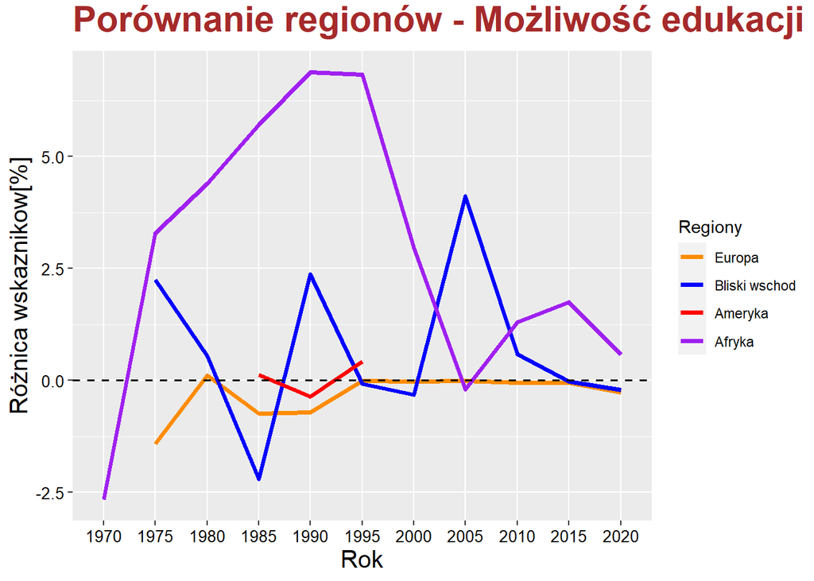

```r
# Tworzenie wskaznika dla kobiet

school_f = out_of_school_f %>%
  filter(as.numeric(year)>=1960)


wskaznik_szkol_f = merge(school_f,populacja_014_f,by="year")


wskaznik_szkol_f = wskaznik_szkol_f %>%
  mutate(bliski_wschod = bliski_wschod.x/bliski_wschod.y*100)%>%
  mutate(europa = europa.x/europa.y*100)%>%
  mutate(ameryka = ameryka.x/ameryka.y*100)%>%
  mutate(afryka = afryka.x/afryka.y*100)%>%
  select(year,bliski_wschod,europa,afryka,ameryka)

wskaznik_szkol_f = wskaznik_szkol_f %>%
  filter(str_ends(year,"5")| str_ends(year,"0"))



# Tworzenie wskaznika dla Mezczyzn

school_m = out_of_school_m %>%
  filter(as.numeric(year)>=1960)


wskaznik_szkol_m = merge(school_m,populacja_014_m,by="year")


wskaznik_szkol_m = wskaznik_szkol_m %>%
  mutate(bliski_wschod = bliski_wschod.x/bliski_wschod.y*100)%>%
  mutate(europa = europa.x/europa.y*100)%>%
  mutate(ameryka = ameryka.x/ameryka.y*100)%>%
  mutate(afryka = afryka.x/afryka.y*100)%>%
  select(year,bliski_wschod,europa,afryka,ameryka)

wskaznik_szkol_m = wskaznik_szkol_m %>%
  filter(str_ends(year,"5")| str_ends(year,"0"))


# Robie roznice wskaznikow : Wskaznik mezczyzn - kobiet

roznica_szkol = merge(wskaznik_szkol_m,wskaznik_szkol_f,by="year")


roznica_szkol = roznica_szkol %>%
  mutate(bliski_wschod = bliski_wschod.y-bliski_wschod.x)%>%
  mutate(europa = europa.y-europa.x)%>%
  mutate(ameryka = ameryka.y-ameryka.x)%>%
  mutate(afryka = afryka.y-afryka.x)%>%
  select(year,bliski_wschod,europa,afryka,ameryka)


legend2 = c("er"="darkorange","bw"="blue","am"="red","af"="purple")
ggplot(roznica_szkol,aes(x=year)) +
  geom_line(aes(color="er",y=europa,group=1),size=1.25) +
  geom_line(aes(color="bw",y=bliski_wschod,group=1),size=1.25) +
  geom_line(aes(color="am",y=ameryka,group=1),size=1.25) +
  geom_line(aes(color="af",y=afryka,group=1),size=1.25) +
  geom_hline(yintercept = 0,size=0.7,linetype="dashed") +
  xlab("Rok")+
  ylab("Różnica wskaznikow[%]")+
  scale_color_manual(name="Regiony",values = legend2,labels = c("Europa","Bliski wschod","Ameryka","Afryka"))+
  ggtitle("Porównanie regionów - Możliwość edukacji") +
  theme(
    plot.title = element_text(hjust = 0,vjust = 1.5,face='bold',size=22,colour =           "brown"),
    axis.text = element_text(size=(10),colour = "black"),
    axis.title = element_text(size = (15)),
    legend.position = "right")
```

## Korelacja między dostępem do edukacji, a poziomem analfabetyzmu

#### W tym podrozdziale, sprawdzę czy istnieje korelacja między dostepem do edukacji, a poziomem analfabetyzmu i wyciągnę na tej podstawie odpowiednie wnioski dla danego regionu oraz płći. Wykorzystam do tego dane o liczbie osób poza szkołą oraz procentową liczbę ludzi umiejących pisać i czytać. Dane obejmują lata od 1975 - 2011. Nie jestem w posiadaniu takich danych dla Ameryki Północnej, z tego względu założę, że jest na tyle rozwiniętym regionem, że sytuacja nie wymaga badań.

```r
# Przygotowanie danych dla kobiet

analfabetyzm_f = literacy_rate_f
dostep_f = out_of_school_f%>%
  filter(as.numeric(year)>=1975)%>%
  filter(as.numeric(year)<=2011)

# Przygotowanie danych dla mężczyzn

analfabetyzm_m = literacy_rate_m
dostep_m = out_of_school_m%>%
  filter(as.numeric(year)>=1975)%>%
  filter(as.numeric(year)<=2011)


# Region: Bliski Wschód
korelacja_bw_f =cor(analfabetyzm_f$bliski_wschod,dostep_f$bliski_wschod,use = "complete.obs",method = "spearman")
korelacja_bw_m =cor(analfabetyzm_m$bliski_wschod,dostep_m$bliski_wschod,use = "complete.obs",method = "spearman")
cat("Korelacja na Bliskim Wschodzie dla kobiet wynosi: ",korelacja_bw_f,"\n")
```

```
## Korelacja na Bliskim Wschodzie dla kobiet wynosi:  0.4671028
```

```r
cat("Korelacja na Bliskim Wschodzie dla mężczyzn wynosi:" ,korelacja_bw_m,"\n" )
```

```
## Korelacja na Bliskim Wschodzie dla mężczyzn wynosi: 0.5254857
```

#### **Region: Bliski Wschód**

#### W tym przypadku została zbadana zależność monotoniczna i po wynikach można zaobserwować, że wsytępuje, ale jest dość przeciętna. Natomiast ciekawą rzeczą jest to, że po wynikach można stwierdzić, iż przy zwiększeniu się liczby osób uczęszczająych do szkoły zmniejsza się poziom ludzi potrafiących czytać i pisać, co jest dość nieintuicyjne i może wskazywać na słaby poziom edukacji w tym regionie. Chciałbym zwrócić także uwagę na małą, aczkolwiek zauważalną różnicę między płciami, która sugeruje, że kobiety lepiej korzystają z edukacji, jeśli jest im udostępniona.

```r
# Region: Europa
korelacja_er_f =cor(analfabetyzm_f$europa,dostep_f$europa,use = "complete.obs")
korelacja_er_m =cor(analfabetyzm_m$europa,dostep_m$europa,use = "complete.obs")
cat("Korelacja w Europie dla kobiet wynosi: ",korelacja_er_f,"\n")
```

```
## Korelacja w Europie dla kobiet wynosi:  -0.6976835
```

```r
cat("Korelacja w Europie dla mężczyzn wynosi:" ,korelacja_er_m,"\n" )
```

```
## Korelacja w Europie dla mężczyzn wynosi: -0.7518297
```

#### **Region: Europa**

```r
# Region: Europa
korelacja_af_f =cor(analfabetyzm_f$afryka,dostep_f$afryka,use = "complete.obs")
korelacja_af_m =cor(analfabetyzm_m$afryka,dostep_m$afryka,use = "complete.obs")
cat("Korelacja w Afryce dla kobiet wynosi: ",korelacja_af_f,"\n")
```

```
## Korelacja w Afryce dla kobiet wynosi:  0.1747862
```

```r
cat("Korelacja w Afryce dla mężczyzn wynosi:" ,korelacja_af_m,"\n" )
```

```
## Korelacja w Afryce dla mężczyzn wynosi: 0.2099563
```

#### Istnieje zależność między dostępem do edukacji, a poziomem analfabetyzmu, co prowadzi nas do następujących wniosków: w regionach bardziej rozwiniętych to mężczyzni efektywniej korzystają z edukacji, natomiast w regionach mniej rozwiniętych, kobiety, które uzyskały dostęp do edukacji lepiej i efektywniej z niej korzystaja.

## Poziom analfabetyzmu

#### W tym rozdziale skupię się na poziome analfabetyzmu po roku 2000(przed tym rokiem było zbyt dużo czynników losowych, aby wysnuć wnioski oraz powinno się skupić na analfabetyzmie obecnie, ponieważ jest to podstawowa potrzeba w dzisijeszych czasach). Pokażę poprzez krzywą gęstości jaka część populacji danej płći potrafi czytać i pisać i na tej podstawie wyciągne odpowiednie konkluzje. Po raz kolejny nie posiadam danych dla Ameryki, dlatego uznam, że występuję na tak nieznaczącym poziomie, że jest to nieznaczące oraz, że nie zależy od płci.

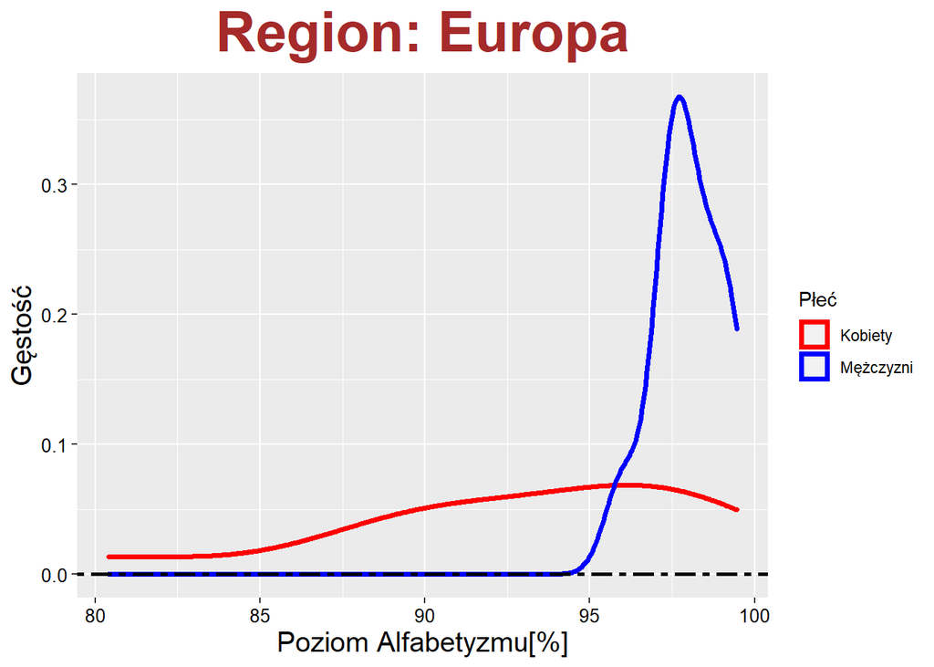

```r
# Region : Europa

# Przygotowanie danych
analf_f= literacy_rate_f %>%
  filter(as.numeric(year)>2000)
analf_m = literacy_rate_m %>%
  filter(as.numeric(year)>2000)


# Wykres
ggplot(NULL,aes(x=europa)) +
  geom_density(data=analf_f,aes(color="k"),size=1.25) +
  geom_density(data = analf_m,aes(color = "m"),size=1.25) +
  geom_hline(yintercept = 0,col="black",linetype="twodash",size=1.05)+
  xlab("Poziom Alfabetyzmu[%]")+
  ylab("Gęstość")+
  scale_color_manual(name="Płeć",values = c("k" ="red","m"="blue"),labels = c("Kobiety","Mężczyzni"))+
  ggtitle("Region: Europa") +
  theme(
  plot.title = element_text(hjust = 0.5,vjust = 1,face='bold',size=30,colour =           "brown"),
    axis.text = element_text(size=(10),colour = "black"),
    axis.title = element_text(size = (15)),
    legend.position = "right")
```

#### Jak widać na wykresie zdecydowanie mężczyzni odnoszą lepsze wyniki, jeżeli chodzi o posiadanie podstawowej wiedzy takiej jak pisanie i czytanie - wskażnik przez lata utrzymywał się na poziomie ponad 94 %, natomaist u kobiet krzywa gęstości jest zdecydowanie bardziej rozłożona, co wskazuje, że pomimo powszechnego dostępu do edukacji, część kobiet nie jest w stanie lub nie chce zdobyć tej wiedzy.

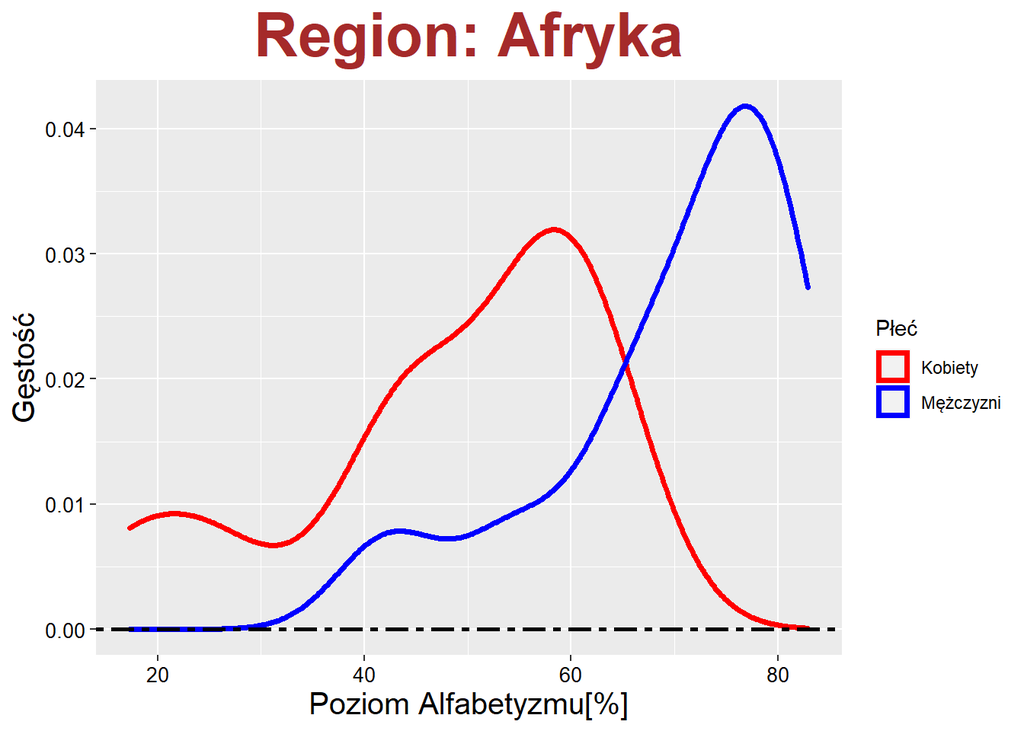

```r
# Region : Afryka


# Wykres
ggplot(NULL,aes(x=afryka)) +
  geom_density(data=analf_f,aes(color="k"),size=1.25) +
  geom_density(data = analf_m,aes(color = "m"),size=1.25) +
  geom_hline(yintercept = 0,col="black",linetype="twodash",size=1.05)+
  xlab("Poziom Alfabetyzmu[%]")+
  ylab("Gęstość")+
  scale_color_manual(name="Płeć",values = c("k" ="red","m"="blue"),labels = c("Kobiety","Mężczyzni"))+
  ggtitle("Region: Afryka") +
  theme(
  plot.title = element_text(hjust = 0.5,vjust = 1,face='bold',size=30,colour =           "brown"),
    axis.text = element_text(size=(10),colour = "black"),
    axis.title = element_text(size = (15)),
    legend.position = "right")
```

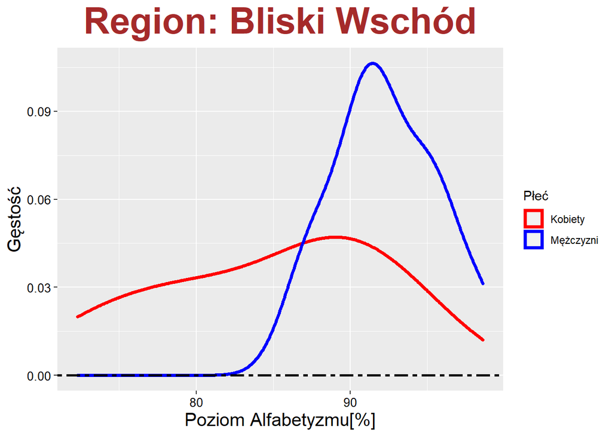

```r
# Region : Bliski Wschód

# Wykres
ggplot(NULL,aes(x=bliski_wschod)) +
  geom_density(data=analf_f,aes(color="k"),size=1.25) +
  geom_density(data = analf_m,aes(color = "m"),size=1.25) +
  geom_hline(yintercept = 0,col="black",linetype="twodash",size=1.05)+
  xlab("Poziom Alfabetyzmu[%]")+
  ylab("Gęstość")+
  scale_color_manual(name="Płeć",values = c("k" ="red","m"="blue"),labels = c("Kobiety","Mężczyzni"))+
  ggtitle("Region: Bliski Wschód") +
  theme(
  plot.title = element_text(hjust = 0.5,vjust = 1,face='bold',size=30,colour =           "brown"),
    axis.text = element_text(size=(10),colour = "black"),
    axis.title = element_text(size = (15)),
    legend.position = "right")
```

## Przekonania kobiet, co do własnego miejsca w społeczeństwie

#### W tym rozdziale wykorzystam ankietę na temat : “Czy mąż jest usprawiedliwiony w danej sytuacji uderzyć swoją żonę(powody podałem przy prezentacji zestawów)”. Powie to wiele o tym jak kobiety same postrzegają swoją rolę w społeczeństwie oraz jakich wartości są nauczane. Wartości w tym zestawie przedstawiają jaki % kobiet odpowiedziało na to powyższe pytanie twierdząco.

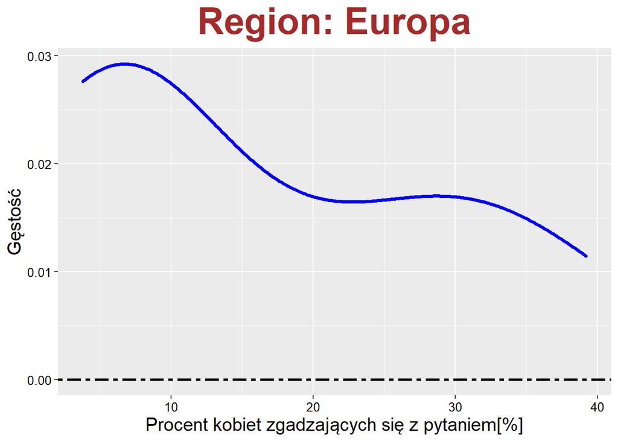

```r
# Region: Europa

ggplot(NULL,aes(x=europa)) +
  geom_density(data=beating_wife,size=1.25,color = "blue") +
  geom_hline(yintercept = 0,col="black",linetype="twodash",size=1.05)+
  xlab("Procent kobiet zgadzających się z pytaniem[%]")+
  ylab("Gęstość")+
  ggtitle("Region: Europa") +
  theme(
  plot.title = element_text(hjust = 0.5,vjust = 1,face='bold',size=30,colour =           "brown"),
    axis.text = element_text(size=(10),colour = "black"),
    axis.title = element_text(size = (15)),
    legend.position = "right")
```

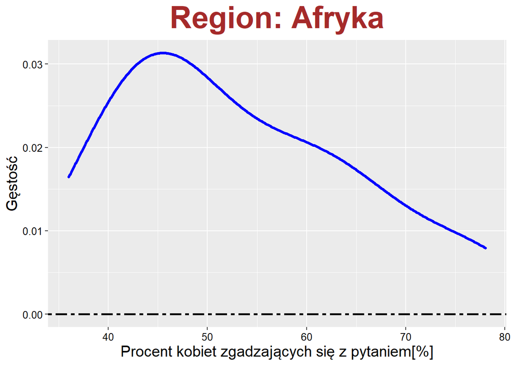

```r
# Region: Europa

ggplot(NULL,aes(x=afryka)) +
  geom_density(data=beating_wife,size=1.25,color = "blue") +
  geom_hline(yintercept = 0,col="black",linetype="twodash",size=1.05)+
  xlab("Procent kobiet zgadzających się z pytaniem[%]")+
  ylab("Gęstość")+
  ggtitle("Region: Afryka") +
  theme(
  plot.title = element_text(hjust = 0.5,vjust = 1,face='bold',size=30,colour =           "brown"),
    axis.text = element_text(size=(10),colour = "black"),
    axis.title = element_text(size = (15)),
    legend.position = "right")
```

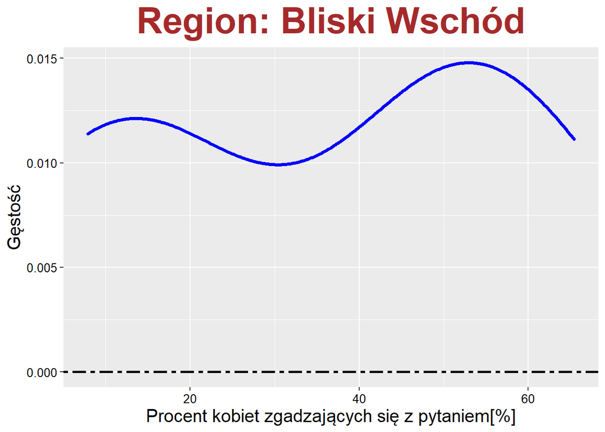

```r
# Region: Bliski Wschód

ggplot(NULL,aes(x=bliski_wschod)) +
  geom_density(data=beating_wife,size=1.25,color = "blue") +
  geom_hline(yintercept = 0,col="black",linetype="twodash",size=1.05)+
  xlab("Procent kobiet zgadzających się z pytaniem[%]")+
  ylab("Gęstość")+
  ggtitle("Region: Bliski Wschód") +
  theme(
  plot.title = element_text(hjust = 0.5,vjust = 1,face='bold',size=30,colour =           "brown"),
    axis.text = element_text(size=(10),colour = "black"),
    axis.title = element_text(size = (15)),
    legend.position = "right")
```

# Podsumowanie Projektu

## Podsumowanie głównej hipotezy badawczej

#### Biorąc pod uwagę powyższe podsumowania potwierdzam moją główną hipotezę badawczą, jako, że dyskryminacja zależy od miejsca. Dyskryminacja wystąpiła na tle edukacji, polityki oraz przekazywania umniejszających wartości na temat ich miejsca w społeczeństwie, głównie w regionach takich jak Afryka oraz na Bliskim Wschodzie. Musze jednak odrzucić moją hipotezę poboczną, jako, że sytuacja kobiet nie ulega zmiania, ponieważ w polityce widzimy trend wzrostowy prowadzący do optymalnej wartośći(oprócz na Bliskim Wschodzie), jeżeli chodzi o edukacje to stan rzeczy też się zmienia na korzyść kobiet.